# Developing a Fiscal Health Index for Nonprofits

What each stage had to solve, what the evidence says, and where the index stands

## How to read this memo

This is a summary of the fiscal health index built in `dev/health-index/`. It reports what each stage of development had to solve and what the evidence supports. It does not reproduce the model-selection work: the choice between three, four, and five dimensions, the triage of individual indicators, and the per-ratio transformation diagnostics live in the source documents.

| Stage | Source document |
| --- | --- |
| Construction strategy | `index-construction.rmd` |
| First (two-dimension) index | `fiscal-health-index-2023.Rmd` |
| Measurement model: coverage rules and normalization | `vignette("variance-preserving-normalization")` |
| Dimension discovery | `dimension-discovery-2023.Rmd` |
| Frozen model, scoring, peer groups | `fiscal-health-model-2023.Rmd` |
| Construction-induced correlation | `vignette("ratio-correlation-artifacts")` |
| H1–H3 asset-liability matching | `matching-hypotheses-2023.Rmd` |
| Matching-gap indicator and its panel test | `matching-gap-2023.Rmd`, `matching-gap-panel.Rmd` |
| H4 revenue model | `h4-revenue-model.Rmd` |
| H5 surplus allocation | `h5-surplus-allocation.Rmd` |

Figures and tables marked *recomputed* are generated here from the saved 321,612-organization 2023 model and from the bundled `dat10k` 2021 sample. Everything else is quoted from the document named in the caption, with numbers taken from its rendered output.

## 1. The measurement problem

Form 990 supports several dozen financial ratios. Most published nonprofit “financial health” work picks a handful of them by argument and averages them. The goal here was different: let the data say how many distinct things the ratios measure, and build the index out of *those*.

That reframes the work as measurement rather than indicator selection, and it sets up the three-way classification that runs through every stage:

**The construction strategy** (`index-construction.rmd`)

- **Dimension.** Two or more indicators that move together closely enough to read as one financial construct, are interpretable, and reproduce across samples. Scored as a composite.
- **Standalone indicator.** A ratio kept in the measurement system but not forced into a dimension, because it shares little variance with the rest and describes something real on its own (a revenue model, an expense allocation).
- **Noise.** Weak connectedness, no distinct conceptual contribution, unstable. Dropped from the measurement system.

The software discovers structure. People decide what to keep, which way each indicator points, and what the dimensions mean.

Two early decisions shaped everything after them.

**PCA as a clustering tool, not a latent-variable claim.** Accounting ratios are not survey items written to tap one trait. A confirmatory factor model treats each indicator as a noisy reflection of a latent construct; a debt ratio is not a noisy reading of “leverage”, it is one of the things leverage *is*. The index therefore uses PCA (with oblique rotation, so dimensions may correlate) to find blocks, then scores each block as a **formative** composite, and reports common-factor analysis as a check that the blocks are not artifacts of unique variance. The formative/reflective distinction is the one drawn by Bollen & Lennox (1991) and Diamantopoulos & Winklhofer (2001); the equal-weight, transparent-aggregation default follows the OECD/JRC composite indicator handbook (Nardo et al. 2008).

**The measurement model comes before the factor model.** A correlation matrix is the only thing PCA sees. Which organizations have a defined value for each ratio, and how extreme values are tamed, decide what is in that matrix. Those decisions were made explicitly and written down before any factoring, which is what makes the difference between the first and second models below legible rather than mysterious.

## 2. First working model: two dimensions

The first end-to-end index ran the package pipeline (`fiscal_diagnostics()` → `fiscal_triage()` → `fiscal_dimensions()` → `fiscal_health_fit()` → `fiscal_health_score()` → `fiscal_weights()` → `fiscal_health_index()`) on 2023 full-990 filers.

### 2.1 Getting the inputs to mean what they claim

Three input problems had to be fixed before any ratio was trustworthy. Each one would have shown up as structure in the correlation matrix.

| Problem | Effect if left alone | Fix |
| --- | --- | --- |
| Part X lines 27–28 (net assets without/with donor restrictions) apply only to filers following SFAS 117 / ASC 958. Others report equity on lines 30–32. | About 1 in 4 filers read as having **zero** unrestricted net assets, so every reserve metric understated their reserves. | When both class lines are zero, use total net assets as unrestricted. |
| `get_overhead_ratio()` omitted fundraising from its numerator, making it identical to the administrative-expense ratio. | A duplicate indicator, and a measure that is by construction the complement of the program-expense ratio. | Corrected numerator; overhead dropped as a closure complement. |
| `get_cash_assets_ratio()` omitted savings and temporary cash investments. | Understated liquidity for organizations that hold cash in savings. | Pass the documented numerator explicitly. |

### 2.2 Screening: the five criteria

Of the 48 metrics in the package registry, 12 passed a screen requiring that an indicator be **directional** (more is clearly better or worse), **scale-free**, **defined for nearly everyone**, **monotone in health**, and **not an algebraic identity** of another indicator. The exclusions that matter most, because they were later reversed:

- **Signed denominators.** Debt-to-equity, debt-to-net-assets, and net-asset growth all have a denominator that can be zero or negative. An insolvent organization with negative net assets gets a *negative* debt-to-net-assets ratio and ranks as the least leveraged. Non-monotone, so excluded.
- **Structural missingness.** The current, quick, and cash-liquidity ratios are undefined for the roughly 40% of filers with no payables. Estimating on complete cases would have quietly dropped the simplest balance sheets.
- **Algebraic identities.** `equity = 1 - debt_assets`, `months_cash_ops = days_cash_ops × 12/365`. Identities make the correlation matrix singular, which breaks KMO and factor estimation and inflates a construct’s apparent weight.

### 2.3 What the transformation had to preserve

The package’s `_z` columns winsorize and then apply a fitted normalizing transform. For correlation-based modeling, the Pearson correlations *after* transformation have to track the monotone association in the raw data — that is the only thing the model can read. Several `_z` pairs shrank strong raw associations toward zero, and several `_z` columns were far from standardized with heavy tails. The first model therefore used rank-normal (van der Waerden) scores, which are bounded, symmetric, outlier-insensitive, and whose Pearson correlations reproduce raw Spearman correlations almost exactly.

### 2.4 The result, and the reason it was not the answer

Triage then removed the redundant and weakly connected members, leaving five indicators in dimension estimation. Parallel analysis retained **two** dimensions, with clean simple structure and agreement from common-factor analysis:

| Dimension | Indicators | Reading |
| --- | --- | --- |
| **Reserves & Solvency** | liquid months (+), days of cash (+), debt/assets (−) | Balance-sheet stocks: resilience |
| **Operating Performance** | surplus margin (+), return on assets (+) | Income-statement flows: sustainability |

The structure was stable — congruence 1.00 across random halves, ≥ 0.94 across a tenfold difference in organization size — and the composite behaved sensibly (every distress signal fell monotonically from the bottom quintile to the top).

**The intellectual contribution of this stage was recognizing what produced the answer.** Two dimensions was a defensible reading of five indicators, but the five indicators were the ones that survived a screen built on the *textbook* form of each ratio. Leverage ratios were excluded because their denominators can be negative; liquidity ratios because they are undefined without payables; asset-composition ratios because their healthy direction is ambiguous. A published four-dimension result on a similar ratio family (the Urban Institute AA/NH/PI study: growth potential, leverage, solvency, organizational slack) had kept those ratios in. The difference was not the factor model. It was which ratios were measured, and how.

## 3. The measurement model: coverage rules and variance-preserving normalization

Rather than drop a ratio because its textbook form fails on part of the sample, the second stage asked, for each failure mode, whether the affected organizations are *better than*, *worse than*, or *typical of* the rest — and then repaired the ratio.

### 3.1 Undefined is not missing at random

> **The rule: rule when the direction is known, impute when it is not.**

| Failure mode | Example | Direction known? | Treatment |
| --- | --- | --- | --- |
| Denominator ≤ 0 and the ratio’s meaning implies the worst state | leverage on negative unrestricted net assets | yes | **Bounded reformulation:** `L / (L + max(UNA, 0))`, monotone with the textbook ratio wherever that is valid, and at the worst end when it is not |
| Growth from a non-positive base | net-asset, revenue, asset growth | yes | **Symmetric growth:** `Δ / mean(\|new\|, \|old\|)`, bounded in [−2, 2], defined whenever either year is nonzero, 0 when both are |
| Margin on near-zero or non-positive revenue | surplus margin | yes | **Symmetric margin:** `(R − E) / max(R, E)` |
| Denominator = 0 because the component does not exist | current ratio with no current liabilities (~40%) | no — ask the data | **Conditional stochastic imputation** from anchor ratios, on the normal-score scale |
| Component not reported | functional expenses of non-501(c)(3) filers | no — missing, not zero | Conditional imputation; never zero |

Three findings from that exercise changed the design:

- **Borrowed benchmarks are wrong on the 990.** A fixed cap like “current ratio = 3”, carried over from corporate finance, sits well below the median of the observed distribution. Bottom-coding a denominator at $1 converts the ratio into a dollar amount for the affected cases.
- **Median imputation is only right if the group is typical.** For every undefined group examined, it was not, and median fills weakened the correlations the index depends on.
- **Closure is a design constraint, not a nuisance.** Program, administrative, and fundraising shares sum to 1. Keeping all three guarantees a component, whatever organizations actually do. One member of each such family is dropped by construction.

### 3.2 Winsorize, then asinh, then z — and freeze it

Four versions of the data were compared as inputs to a correlation model: raw (rules applied), winsorized, winsorized + normalized, and rank-normal. The recommended default is **percentile winsorizing (1/99), then `asinh` with a robust median scale for ratios that remain skewed, then a z-score**. The inverse hyperbolic sine is used as a log-like transform that tolerates zero and negative values (Johnson 1949; Burbidge, Magee & Robb 1988).

It was chosen over rank-normal for two reasons. It keeps interval spacing inside the body of each distribution — a 2-month and a 20-month reserve differ by more than their ranks — and every one of its parameters (bounds, skew direction, `asinh` scale, mean, SD) can be **stored and reapplied**, so a later year is placed on the reference year’s scale instead of being re-ranked within itself. Rank-normal remains the robustness check.

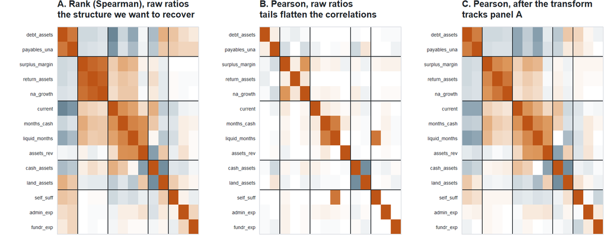

Orange is positive, blue negative, on a −1 to +1 scale; rule lines mark the dimensions the ratios were eventually assigned to. Panel A is the target: the monotone association actually present in the raw ratios. Panel B is what a correlation model sees if the ratios go in untreated — a handful of extreme values flatten most of the matrix, including the blocks that later become dimensions. Panel C is the recommended transform, which recovers panel A.

Recomputed. Fidelity to the rank benchmark, 91 pairs, dat10k 2021 (n = 5,995)

|  | mean \|r\| | mean \|r − rank r\| | max \|r − rank r\| |
| --- | --- | --- | --- |
| Raw ratios (Pearson) | 0.059 | 0.184 | 0.875 |
| Winsorized only | 0.133 | 0.115 | 0.506 |
| Winsorized + asinh + z | 0.181 | 0.058 | 0.266 |
| Rank-normal | 0.204 | 0.022 | 0.071 |

Winsorizing alone is not enough: skew survives it and the correlations stay visibly distorted. Winsorize + `asinh` + z gets most of the way to rank-normal fidelity while keeping spacing and remaining reusable.

**What this bought.** Coverage rose to every full-990 filer with positive expenses, including organizations with no assets, no revenue, or no payables. Thirteen ratios entered dimension estimation instead of five.

## 4. Four dimensions, three of them directional

Quoted from dimension-discovery-2023.Rmd. PCA (oblimin) loadings below 0.30 blanked; all 2023 full-990 filers

|  | leverage | performance & growth | reserves | asset structure |
| --- | --- | --- | --- | --- |
| current | -0.40 |  | 0.41 |  |
| months_cash |  |  | 0.85 |  |
| liquid_months |  |  | 0.76 |  |
| cash_assets |  |  |  | 0.88 |
| debt_assets | 0.88 |  |  |  |
| payables_una | 0.92 |  |  |  |
| surplus_margin |  | 0.71 |  |  |
| return_assets |  | 0.88 |  |  |
| na_growth |  | 0.87 |  |  |
| land_assets |  |  |  | -0.80 |
| assets_rev |  |  | 0.77 | -0.47 |
| rev_growth |  | 0.59 |  |  |
| asset_growth |  | 0.87 |  |  |

Component correlations

|  | leverage | performance & growth | reserves | asset structure |
| --- | --- | --- | --- | --- |
| leverage | 1.00 | -0.16 | -0.29 | -0.18 |
| performance & growth | -0.16 | 1.00 | 0.12 | 0.14 |
| reserves | -0.29 | 0.12 | 1.00 | -0.02 |
| asset structure | -0.18 | 0.14 | -0.02 | 1.00 |

The retention criteria disagreed, as they usually do: PCA parallel analysis and the Kaiser rule both kept four, factor-analytic parallel analysis five, and Velicer’s MAP — which under-extracts when dimensions have only two to four indicators — one. Four was retained because it is the largest solution in which **every** dimension is an interpretable multi-indicator cluster. Three merges leverage into reserves; five breaks asset structure into near-singletons while splitting reserves into short-term liquidity and accumulated reserves, a split worth testing on panel data but not worth trading a coherent dimension for.

### 4.1 The index

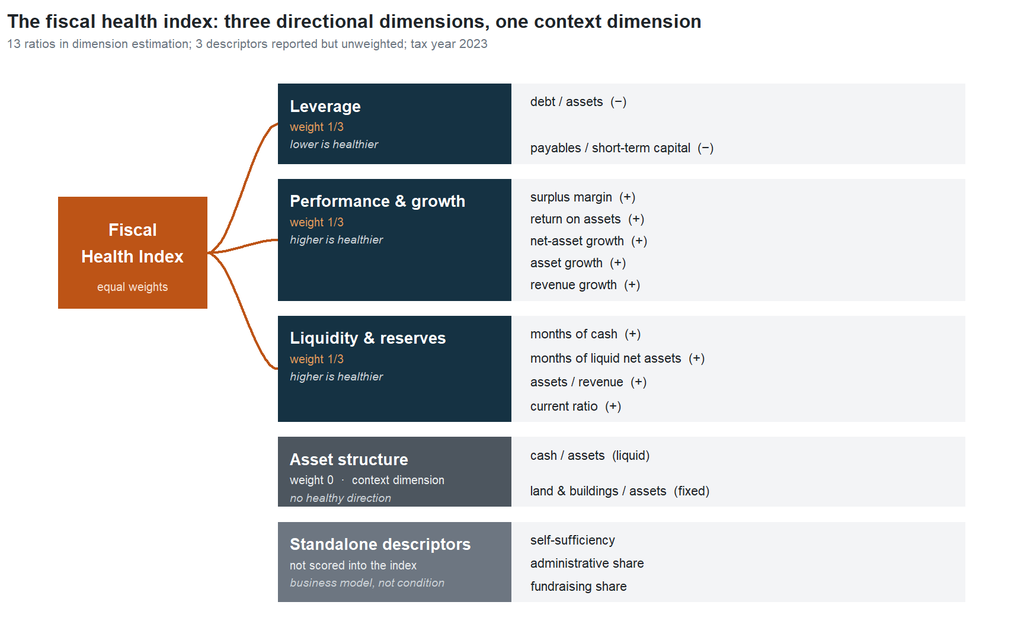

Three contributions are embedded in that picture.

**Leverage is its own dimension.** Once negative-equity denominators are handled with a bounded reformulation, debt-to-assets and the payables share form a clean two-indicator block that correlates only −0.29 with reserves. Organizations can hold large reserves *and* significant mortgage debt, or neither. Averaging the two, as the first model did, discards that.

**Growth belongs to performance, and needs no panel.** One 2023 return reports both years: Part I lists prior- and current-year revenue, Part X beginning- and end-of-year assets. Measured symmetrically, asset growth loads 0.87 and revenue growth 0.59 on performance and nowhere above 0.14 elsewhere. Single-return growth agrees with true 2022–2023 panel growth almost exactly, and it covers every filer rather than only the ~86% with a matched prior return.

**Asset structure is a *context* dimension.** Cash share and property share form a stable, reproducible component — and it has no healthy direction. A hospital or a housing provider is not less healthy than a cash-based advocacy group; it runs a different business model. Rather than force a direction or discard a real dimension, the model scores it, reports it, and gives it **zero weight**. It is meant to be used as a stratifier or control. Naming this category is the single most useful conceptual move in the dimension work: it separates “what kind of organization is this” from “how is it doing”.

**Organizational slack did not reappear.** The AA/NH/PI study’s slack dimension paired the administrative-expense ratio with the program-efficiency ratio. Those two are complements by construction, so they form a component regardless of organizational behavior. With the complement removed, no slack dimension appears — and the three expense/revenue-model ratios have near-zero communality, which is why they are reported as standalone descriptors.

### 4.2 Stability

Quoted from dimension-discovery-2023.Rmd. Tucker congruence; 0.95+ means effectively the same factor

| comparison | n | performance | reserves | leverage | asset structure |
| --- | --- | --- | --- | --- | --- |
| Random half A vs. half B | 160,806 | 1.00 | 1.00 | 1.00 | 1.00 |
| Expenses < $500k vs. full sample | 171,273 | 1.00 | 1.00 | 0.99 | 1.00 |
| $500k–$5M vs. full sample | 111,728 | 1.00 | 0.99 | 0.99 | 1.00 |
| >= $5M vs. full sample | 38,611 | 0.99 | 0.95 | 0.96 | 0.97 |
| Rank-normal vs. winsorized + normalized | 321,612 | 1.00 | 0.99 | 0.99 | 0.99 |
| Winsorize 5/95 vs. 1/99 | 321,612 | 1.00 | 1.00 | 1.00 | 1.00 |
| Winsorized only (no asinh) | 321,612 | 0.99 | 0.99 | 0.94 | 0.99 |
| 2021 sample (dat10k) vs. 2023 | 6,207 | 1.00 | 1.00 | 1.00 | 1.00 |

The four dimensions reproduce essentially perfectly across random halves, the two smaller size bands, both winsorizing levels, rank-normal scoring, and an independent 2021 sample. Two soft spots are worth carrying forward. Among organizations with expenses over $5M, the reserve–leverage boundary shifts: their current ratio and liquid months load substantially on leverage, because liquid unrestricted net assets are largely what is left after debt-financed property. And winsorizing *without* normalizing blurs leverage the most (congruence 0.94), which is direct evidence that residual skew, not organizational behavior, was weakening the debt-ratio correlations.

### 4.3 Scoring the frozen model

Each dimension is scored as the **standardized mean of its oriented indicators**, and the composite is an equal-weight average of the three directional dimensions. Standardized means correlate at least 0.97 with factor-weighted scores and 1.00 with PCA-weighted ones, and they do not make the scale depend on one year’s estimates — factor weights would concentrate performance on return on assets and net-asset growth, and reserves on months of cash. No cross-section can calibrate weights against an outcome, so equal weights across dimensions are the defensible default rather than an estimate.

Quoted from fiscal-health-model-2023.Rmd. Cronbach’s alpha on oriented indicators

| dimension | indicators | alpha | weakest_member |
| --- | --- | --- | --- |
| leverage | 2 | 0.807 | — |
| performance & growth | 5 | 0.844 | rev_growth (item-rest 0.43) |
| reserves | 4 | 0.760 | current (0.43) |
| asset structure (context) | 2 | 0.677 | — |

Every indicator correlates positively with the rest of its dimension once oriented, which confirms the directions are internally consistent. The alphas should be read with care rather than as evidence of a latent trait: the performance alpha is partly mechanical (three of its five indicators are built from the same annual surplus), and the leverage and reserve alphas are held down by mixing assets with liabilities. These are formative summaries of a coherent block of ratios.

The fitted object stores every parameter — winsorizing bounds, transform type and scale, centers, scales, directions, dimension coefficients, weights, and peer-group percentile cut points — so scoring new data re-estimates nothing.

## 5. The correlation problem: bounded ratios with shared parts

The four-dimension model works, reproduces, and behaves sensibly. That raised the question that most of the analytic effort went into: **are those dimensions findings about nonprofits, or arithmetic?**

Fourteen ratios are built from about twenty Form 990 lines. Many share a line. Shares of one total are negatively correlated by definition. This is the oldest known hazard in ratio analysis — Pearson (1897) on spurious correlation among indices with a common divisor, Chayes (1949) on correlation among percentages of a constant sum, Atchley, Gaskins & Anderson (1976) on the statistical properties of ratios, Firebaugh & Gibbs (1985) and Kronmal (1993) on ratio variables in regression, and the compositional-data tradition of Aitchison (1982, 1986).

### 5.1 How two ratios can be linked

All 91 pairs of the 14-ratio set were classified from the formulas alone, before looking at data

| Link type | Example | Forced sign |
| --- | --- | --- |
| closure | cash/assets & land/assets (parts of assets) | − |
| shared numerator | surplus margin & return on assets (both carry R − E) | sign of the numerators |
| reciprocal | current ratio & debt/assets (current assets sit inside assets; payables inside liabilities) | − |
| identity | debt/assets & net-asset growth (NA = A − L) | varies |
| shared denominator | months of cash & admin share (both divide by expenses) | + for positive numerators |
| none | debt/assets & self-sufficiency | 0 |

Recomputed from the saved vignette run. dat10k 2021 (n = 5,995), 30 null replications

| Link type | Pairs | Mean \|r\| observed | Mean \|r\| construction null | Null share of observed |
| --- | --- | --- | --- | --- |
| shared_num | 10 | 0.331 | 0.364 | 1.215 |
| identity | 16 | 0.248 | 0.267 | 1.116 |
| reciprocal | 11 | 0.237 | 0.252 | 1.095 |
| closure | 2 | 0.326 | 0.281 | 0.862 |
| shared_den | 24 | 0.145 | 0.045 | 0.368 |
| none | 28 | 0.088 | 0.017 | 0.196 |

### 5.2 The construction null

The benchmark is a **construction null**: each 990 line is divided by a size reference, shuffled across organizations independently of every other line, multiplied back, and the totals rebuilt from their parts, so every accounting identity survives. The ratios are then rebuilt with exactly the same rules, imputation, and transformations as the real data. Every substantive relationship between organizations is destroyed; all the arithmetic is kept. This is a domain-specific replacement for Horn’s (1965) random-data reference in parallel analysis, in the spirit of null-model testing (Gotelli & Graves 1996): the right question is not “could random numbers do this?” but “could the formulas do this?”

Because denominator coupling is an artifact only to the extent that the denominator varies independently of size, the null is run under more than one size reference: a **flow anchor** (total expenses), a **stock anchor** (total assets), and — after the first two proved to be the weak link — a **conditional** null in which organizations are grouped into cells of similar expenses and similar assets per dollar of expenses, each keeps its own expenses, and lines are shuffled only within cells. The conditional null preserves the arithmetic *and* every relationship that runs through size and asset intensity. A correlation that exceeds it cannot be explained by either.

### 5.3 The answer: mostly arithmetic

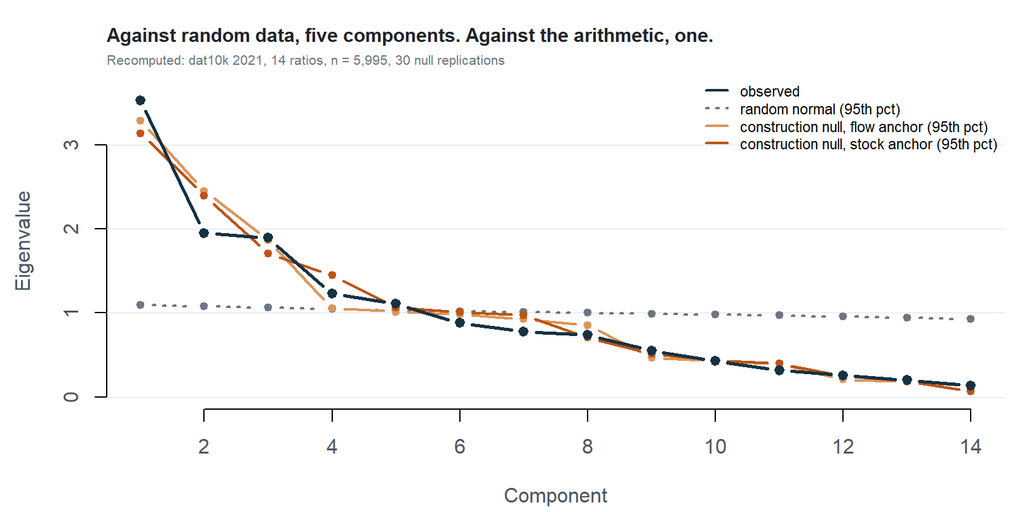

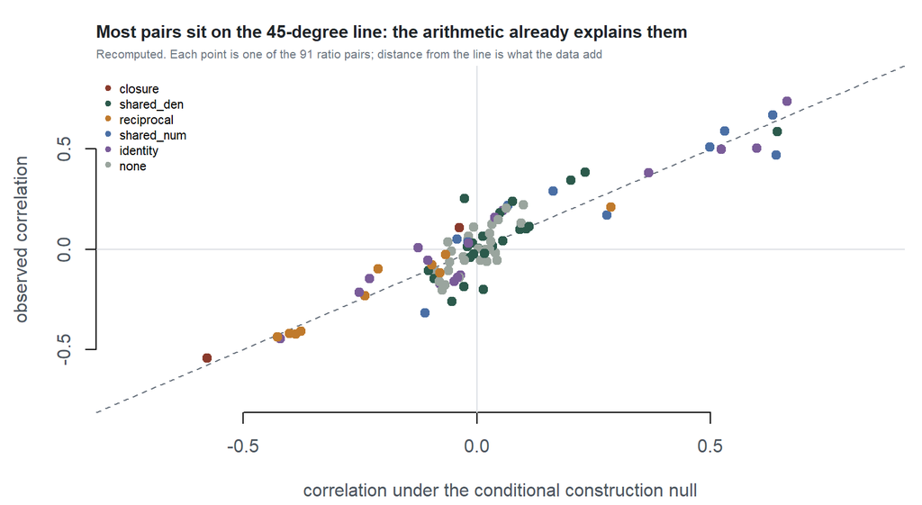

- The sign predicted from the formulas alone matched the null for 91% of the 32 pairs whose null correlation reaches 0.05, and 82% of unlinked pairs stayed below 0.05. The taxonomy is not a post-hoc story.
- For shared-numerator, identity, and reciprocal pairs the null reproduces **all or more than all** of the observed absolute correlation. Only shared-denominator pairs (37%) and unlinked pairs (20%) carry mostly non-arithmetic correlation.
- Parallel analysis against random normal data retains 5 components. Against the construction null it retains 1.
- PCA on the null matrix reproduces the observed dimensions. Under the conditional null the congruence is 0.99 for performance, 0.97 for reserves, 0.94 for leverage, and 0.98 for asset structure.

The mechanism is not subtle once named. Surplus margin, return on assets, and net-asset growth are **one number — the annual surplus — on three scales**. Months of cash, months of liquid net assets, and assets-per-revenue all inherit the ratio of assets to expenses. The dimensions are, to a first approximation, shared-ingredient groupings.

### 5.4 Candidate fixes, and what happened to each

Recomputed. Five candidate repairs, tested against the construction null and against planted factors

[output not shown]

The planted-factor test is what separates the last row from the rest. Three known factors were planted in the 990 *lines* through a Gaussian copula — each line keeps its exact distribution but co-moves with the others that share its factor — and then the ratios were rebuilt. A second scenario plants nothing. Only the *gap* between recovery-when-planted and recovery-when-nothing-is-planted is evidence that a method reads organizational structure rather than arithmetic. Ordinary factor analysis scores 0.87 against the planted structure when factors are planted and 0.84 when they are not: a margin of 0.03. It was reading the formulas nearly as well as it read the truth.

### 5.5 What actually worked

**No pre-processing transformation removes the artifact across all 91 pairs.** The artifact lives in different places for different link types, so a single per-variable transform cannot reach all of them, and the ones that reach furthest do it by deleting the variable’s variance.

Three things did work:

1. **The null as a benchmark rather than a correction.** Retention decisions, loading interpretation, and reported correlations are all read against the construction null instead of against random data. This is the one step that applies to all 91 pairs, and it is now the standard the index is held to.
2. **Designing the variable set to avoid the worst link types.** Closure pairs become one bounded contrast; a shared-ingredient family enters once. The redesigned set does not have less construction correlation overall, but its structure survives the null.
3. **Putting the arithmetic into the model instead of removing it from the data.** Fixing the null’s off-diagonal as a known residual covariance block leaves the observed matrix intact and asks the factors to explain only what the arithmetic does not. It recovers planted factors where ordinary factor analysis cannot — **but only when the null is specified correctly.** With a global flow or stock anchor the margin collapses, and the model starts producing single-variable “factors” that absorb the misfit between the real and assumed construction. That dependence is the method’s cost, and it is why the conditional null exists.

**The consequence for the index, stated plainly:** the four dimensions are sound as *descriptive summaries* of how nonprofit financial ratios are put together, and they are the right way to aggregate the ratios into a score. They are not evidence of four latent financial constructs. The claim the evidence supports is weaker and more useful: these are the blocks the 990 gives you, they are stable, and they carry real information about condition — but the block structure itself is largely definitional.

### 5.6 What survives the null, and the H1–H5 agenda

Recomputed. The correlations a factor model of this set would be entitled to interpret

| Ratio pair | Observed r | Conditional null r | Beyond null | Motivated |
| --- | --- | --- | --- | --- |
| debt_assets × land_assets | 0.25 | -0.03 | 0.28 | H1 / H1a long-term matching |
| self_suff × fundr_exp | -0.20 | 0.01 | -0.21 | H4 earned revenue vs. fundraising |
| cash_assets × debt_assets | -0.26 | -0.05 | -0.21 | H3 pecking order |
| liquid_months × land_assets | -0.32 | -0.11 | -0.21 | H1 long-term matching |
| months_cash × assets_rev | 0.47 | 0.64 | -0.17 | — the reserve scale itself |
| months_cash × return_assets | 0.24 | 0.08 | 0.16 | H5 surplus allocation |
| debt_assets × return_assets | -0.19 | -0.03 | -0.16 | — leverage vs. performance |

A handful of pairs stand clearly off the 45-degree line. Those became the hypotheses in Section 6.3 — not as correlations between ratios, but as regressions on the underlying dollar lines, each pre-specified with a support and rejection rule before estimation. **This is the productive use of the null result:** it converts “the index has four dimensions” into a short list of testable claims about nonprofit financing behavior.

## 6. Is the index meaningful?

### 6.1 Sanity checks

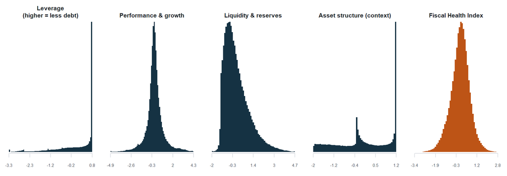

Recomputed from the saved 2023 model (n = 321,612)

|  | mean | sd | 5% | 25% | 50% | 75% | 95% |
| --- | --- | --- | --- | --- | --- | --- | --- |
| fh_leverage | 0 | 1.00 | -2.33 | -0.51 | 0.46 | 0.79 | 0.79 |
| fh_performance_growth | 0 | 1.00 | -1.58 | -0.40 | -0.04 | 0.37 | 1.70 |
| fh_reserves | 0 | 1.00 | -1.19 | -0.74 | -0.23 | 0.51 | 1.98 |
| fh_asset_structure | 0 | 1.00 | -1.73 | -0.79 | -0.03 | 1.07 | 1.23 |
| fiscal_health | 0 | 0.71 | -1.23 | -0.42 | 0.03 | 0.44 | 1.11 |

Score correlations

|  | fh_leverage | fh_performance_growth | fh_reserves | fh_asset_structure | fiscal_health |
| --- | --- | --- | --- | --- | --- |
| fh_leverage | 1.00 | 0.14 | 0.43 | 0.23 | 0.74 |
| fh_performance_growth | 0.14 | 1.00 | 0.17 | 0.07 | 0.62 |
| fh_reserves | 0.43 | 0.17 | 1.00 | 0.09 | 0.76 |
| fh_asset_structure | 0.23 | 0.07 | 0.09 | 1.00 | 0.18 |
| fiscal_health | 0.74 | 0.62 | 0.76 | 0.18 | 1.00 |

The distributions raise one real feature and one real limitation.

- **The leverage ceiling is genuine.** Its 75th and 95th percentiles are identical because 28.7% of filers sit at the single best possible value: no liabilities and no payables. Having no debt *is* the least-leveraged state, so the tie is not a measurement artifact — but it does mean the leverage score cannot discriminate within its top quarter.
- **Dimension scores carry information the composite hides.** The three directional dimensions correlate only 0.14–0.43 with one another. Sorting organizations by whether each dimension is above or below its median, 60% of organizations have a *mixed* profile — well-reserved but running a deficit, or earning surpluses on a thin balance sheet. A single composite puts those in the same place, which is why the index reports all four scores alongside it.

Quoted from fiscal-health-model-2023.Rmd. Raw 2023 conditions by index quintile

| Quintile | n | Deficit | Negative net assets | Negative liquid reserves | < 1 month cash | Revenue down > 20% | Liabilities > 50% of assets | Median expenses |
| --- | --- | --- | --- | --- | --- | --- | --- | --- |
| 1 | 64,323 | 70.9% | 23.9% | 33.6% | 25.3% | 20.8% | 53.1% | 1,090,873 |
| 2 | 64,323 | 51.5% | 1.2% | 8.9% | 11.2% | 16.5% | 14.0% | 877,187 |
| 3 | 64,322 | 39.7% | 0.2% | 3.2% | 7.2% | 15.7% | 4.7% | 495,802 |
| 4 | 64,322 | 25.2% | 0.1% | 1.5% | 4.4% | 15.6% | 2.2% | 322,006 |
| 5 | 64,322 | 12.7% | 0.0% | 0.8% | 3.5% | 13.7% | 1.1% | 139,302 |

Every distress signal falls monotonically from the bottom quintile to the top, and balance-sheet distress is concentrated in the bottom fifth. This check is partly circular — these conditions feed the index — so what it establishes is narrower than it looks: orientation, transformation, and weighting behave as intended on the raw scale, including at the extremes that the transform compresses. Two honest caveats fall out of it:

- **Revenue declines barely sort.** A 20% revenue drop is only slightly more common in the bottom quintile than the top. Revenue growth is one of five performance indicators and the weakest-loading one, and a single year’s revenue decline is a noisy distress signal by itself.
- **The top quintile is the *smallest* organizations.** Median expenses fall from $1.09M to $139k across quintiles. Small organizations more often carry no debt and hold reserves that are large relative to their spending. The index measures condition *relative to scale*, not institutional strength.

**Reusability.** Fitting the normalizer and the model on a random half of 2023 filers and scoring the other half reproduces the full-sample scores essentially exactly, with matching means and standard deviations. The stored parameters, not the scoring sample, define the scale.

### 6.2 Variance across subsectors and organization size

Quoted from fiscal-health-model-2023.Rmd. Share of score variance (R-squared) explained by peer definitions

| Score | Size band | Peer sector | Sector + size |
| --- | --- | --- | --- |
| Leverage | 0.146 | 0.070 | 0.194 |
| Performance & growth | 0.004 | 0.003 | 0.007 |
| Liquidity & reserves | 0.101 | 0.044 | 0.139 |
| Asset structure | 0.046 | 0.091 | 0.136 |
| Fiscal Health Index | 0.127 | 0.040 | 0.153 |

Three results here matter for how the index should be used.

**Most variation is within peer groups.** Sector and size together explain 15% of composite variance, so national scores remain meaningful.

**Size matters more than sector, and it acts through the balance sheet.** Size band alone explains 13% of composite variance against 4% for sector, and it works almost entirely through leverage and reserves. Performance & growth is nearly flat across both — 1% explained. That asymmetry is itself a finding: *how an organization finances itself* is strongly structured by what it is and how big it is; *whether it ran a surplus this year* is not.

**Between-group differences are large enough to need peer benchmarks.** Median national percentile runs from 21 (hospitals) to 70 (public safety & relief, mutual & membership benefit).

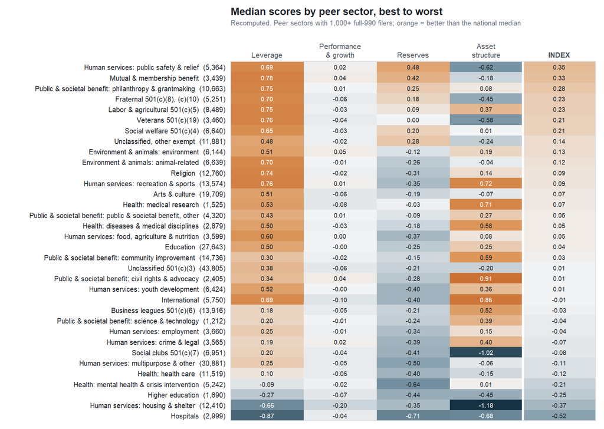

The heat map shows why asset structure is reported as context. Hospitals, higher education, and housing providers sit at the bottom of the index on leverage and reserves while having *strongly negative* asset-structure scores (fixed-asset-heavy). Their low health scores are substantially a statement about their business model. Read down the performance & growth column: it is near zero for almost every sector. The composite’s sector spread is a balance-sheet spread.

Quoted from fiscal-health-model-2023.Rmd. Effect of peer-group benchmarking

| Check | Value |
| --- | --- |
| Spearman rho, peer vs. national composite percentile | 0.878 |
| Median absolute shift, national to peer (points) | 10 |
| Organizations shifting 20+ percentile points | 13.9% |
| Organizations shifting 40+ percentile points | 1.5% |

Peer percentiles (NTEE v2 subsector, split into NTEE major groups where a subsector spans several, with IRS subsection as a fallback, crossed with three expense bands, minimum 250 per group) re-base the score without reordering it wholesale. The recommendation is to report both: a low peer percentile flags an organization weak *even by its field’s norms*, while a low national percentile with a typical peer percentile says the weakness is the field’s financial model.

### 6.3 H1–H5: does the index’s structure reflect real behavior?

Five hypotheses were drawn from the pairs that survived the conditional null (Section 5.6). Each was pre-specified — outcome, carrying coefficient, support rule, rejection rule — before estimation, and tested on 990 **dollar lines** rather than on ratios, with size controls and an evidence rule requiring the estimate to lie beyond the 0.5th/99.5th percentile of 200 refits in which the predictor is shuffled within cells of expenses × asset intensity.

Quoted from matching-hypotheses-2023.Rmd, h4-revenue-model.Rmd, h5-surplus-allocation.Rmd

| Hypothesis | 2023 verdict | Replication | Key estimate |
| --- | --- | --- | --- |
| **H1** Fixed assets are financed with long-term debt | **supported** | 2021: supported | elasticity of long-term debt to fixed assets 0.51; 0.45 larger than in the short-term equation |
| **H1a** Matching is stronger in capital-intensive subsectors | **rejected** | 2021: rejected | interaction with hospitals, universities, housing −0.13 (wrong sign) |
| **H2** Non-cash current assets are financed with short-term liabilities | **supported** | 2021: supported | elasticity 0.20; 0.20 larger than in the long-term equation |
| **H3** Organizations with more cash carry less long-term debt | inconclusive | 2021: inconclusive | −0.026 on having any long-term debt (passes), but +0.002 on the amount (fails) |
| **H4** Organizations that earn revenue spend less on raising it | **supported** | panel: weak/contrary | log program revenue: −0.037 on any fundraising, −0.062 on the amount, with contributions +0.069 / +0.280 |
| **H5** Where does a surplus go? | estimated (no directional prediction) | 2019, 2021, 2022, 2023 | 37 cents of each surplus dollar ends as cash, 32 as investments and other assets, 14 as property, 12 as liabilities paid down |

**H1 and H2 (supported, and replicated).** Long-term debt tracks fixed assets; short-term liabilities track non-cash current assets; each is stronger in its own equation than in the other’s. Both replicate in the independent 2021 sample. This is the clearest substantive finding in the programme: the leverage-reserves separation the four-dimension model insists on corresponds to a real financing pattern, not only to how the ratios divide.

**H1a (rejected).** Matching is not stronger in capital-intensive subsectors — the interaction has the wrong sign in both years. Hospitals, universities, and housing providers match *less* tightly, plausibly because they use tax-exempt bonds and multi-project financing that is not tied to a single asset.

**H3 (inconclusive, both years).** More cash goes with a lower probability of holding long-term debt, but among borrowers it has no relationship with the amount. A pecking-order reading and a collateral reading are both consistent with that.

**H4 (supported in cross-section; not within organizations).** Organizations with more program service revenue are less likely to report fundraising expense and report less of it, while contributions push both up sharply — a clean substitution pattern. But the same organizations, followed over time, do not behave that way: within-organization, a 1-unit rise in log program revenue goes with a **+0.014** change in log fundraising expense, and organizations that lost the most earned revenue in the pandemic did **not** raise fundraising effort by 2023 (coefficient 0.0054, SE 0.0050, i.e. the wrong sign and indistinguishable from zero). **Between-organization substitution is a difference in business model, not a behavioural margin organizations move along.** That distinction is easy to miss and changes the policy reading entirely.

**H5 (the allocation itself).** H5 makes no directional prediction; the estimate *is* the finding, and the accounting identity is the check on it.

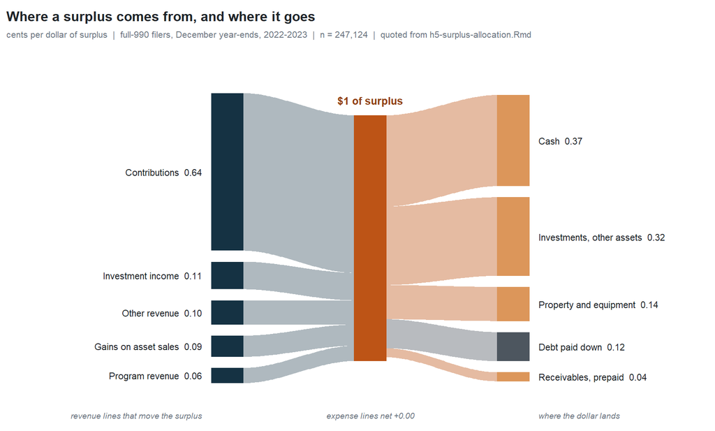

The identity is the quality control, and it holds: asset-side coefficients minus liability-side coefficients sum to 0.985, matching the 0.985 from regressing the change in net assets directly on the surplus. Almost every surplus dollar is traceable.

Three things fall out of the split:

Robustness: the split is stable under organization fixed effects (cash 0.434 within-organization vs. 0.371 pooled) and across 2019, 2021, 2022, and 2023, with property’s share falling from 0.214 pre-COVID to 0.139 in 2022–23. An early version of this analysis winsorized each component separately, which broke the identity — the identity check caught it, and outliers are now handled by dropping organization-years rather than clipping values.

### 6.4 A negative result worth keeping: the matching-gap indicator

Because H1 and H2 held, they were turned into a candidate **indicator**: fit the two benchmarks, predict how much debt an organization’s asset mix and size support, and define the *matching gap* as actual minus predicted debt over assets. A positive gap means more debt than similar organizations with the same assets carry. Validation expectations were, again, written in advance.

Quoted from matching-gap-2023.Rmd and matching-gap-panel.Rmd

| Test | Result |
| --- | --- |
| One year ahead, within the 2023 filing (planned controls) | Cash drawdown: +0.057 per SD, **+0.041 AUC** over debt/assets alone. Deficits and net-asset declines: AUC gain ≤ 0.001. |
| Same, controlling for starting cash months and asset intensity | Cash-drawdown coefficient 0.001, AUC gain 0.0000. **The planned association was a floor effect** — cash cannot fall by a month of expenses unless you start with that much. |
| Poisson (PPML) benchmark instead of the two-part model | Matches total dollars by construction, where the two-part model over-predicted by 2.3×. With the added controls, the largest AUC gain for deficits or net-asset declines is 0.003. |
| 2019 gap predicting 2020–2023 (deficits, net-asset decline, stopped filing) | Largest AUC gain from adding the gap to a model with debt/assets, size, cash months and asset intensity: **0.0005**. |
| Persistence: 2019 gap vs. 2023 gap (Spearman) | 0.64 (assets-scaled), 0.71 (expense-scaled) — a standing financing posture, not a passing strain. |

The matching gap **does not predict distress** beyond what debt-to-assets, size, starting liquidity, and asset intensity already say. Three methodological lessons are worth more than the indicator would have been:

1. **A confirmed correlation is not a useful indicator.** H1 and H2 replicate and survive the construction null, and the gap built from them still adds nothing.
2. **The first strong result was mechanical.** Pre-specifying the validation did not protect against it; only asking *why* the association existed did. Floor effects of this kind are the main risk in any “fell by more than X” outcome, and they should be controlled for by design.
3. **Retransformation bias is not a detail.** The planned two-part (logit + log-OLS with Duan smearing) benchmark over-predicted total debt by a factor of 2.3. PPML on dollars with zeros included matches totals by construction and is the right default for this kind of benchmark.

There is one hint worth following: **the relationship is not monotone.** Among the most leveraged third of organizations in the panel, both the highest-gap quintile (32% with three or more deficit years over 2020–2023) and the lowest-gap quintile (21%) fare worse than the middle (17%). Organizations far above the benchmark are over-borrowed; those far below it tend to hold thin balance sheets relative to their spending. A linear term averages the two away, and an absolute-deviation specification does slightly better — though still with AUC gains under 0.003.

## 7. Where index development stands

### Clear strengths

- **The measurement model is explicit, complete, and reusable.** Every ratio has a documented rule for each way it can fail; nothing is dropped for convenience; the transformation’s parameters are stored, so 2024 can be scored on the 2023 scale. Coverage is every full-990 filer with positive expenses (321,612 organizations).
- **The dimension structure is as stable as this kind of result gets.** Congruence ≥ 0.94 across random halves, three size bands, two winsorizing levels, two transformation families, and an independent tax year.
- **Every substantive decision is on the record with its reasoning**, including the ones later reversed. The path from two dimensions to four is legible because the screening rules were written down.
- **The index behaves sensibly.** Distress signals fall monotonically across quintiles; half-sample fits reproduce full-sample scores; the leverage tie at the top is a real feature of the sector, not a bug.
- **Its main weakness has been quantified rather than assumed.** The construction null puts a number on how much of the structure is arithmetic, and the answer is “most of it”. Very few composite indices in this literature have been tested this way.
- **Three substantive findings hold up.** Long- and short-term asset-liability matching (H1, H2) replicate in an independent year, and the allocation of a surplus dollar (H5) is stable across 2019, 2021, 2022 and 2023 while holding the accounting identity to within 1.5%.

### Limitations

- **No predictive validity yet.** The decisive test is whether a low 2023 score precedes deficits, insolvency, or stopping filing. Everything so far is face validity plus cross-sectional association. The one predictive test that *was* run — the matching gap over 2019–2023 — came back null.
- **Equal weights are a default, not an estimate.** Nothing in a cross-section can calibrate them.
- **The dimensions are not established as latent constructs.** Section 5 is explicit: arithmetic alone reproduces them with congruence 0.94–0.99. They are the right way to *aggregate* the 990’s ratios; they are not four discovered facts about nonprofit finance.
- **The index is monotone without limit.** More reserves and larger surpluses always score better. There is no excess-reserves penalty or target range, which means multi-year capital campaigns and large endowments score as maximal health.
- **Scores are structured by size and business model.** Size band explains 13% of composite variance, sector 4%, and the top quintile is the smallest organizations. Peer percentiles mitigate this but do not remove it, and roughly a third of full-990 filers have no usable NTEE code.
- **Out of scope: 990-EZ and 990-N filers**, i.e. most nonprofits by count.
- **The pipeline is still half in dev scripts.** `build-ratio-frame.R` and the frozen-normalization helpers are not in the package, so the model cannot yet be refit or applied without them. Several package fixes identified along the way are still outstanding, including the `_z` zero-MAD failure on zero-inflated shares.

### Reasonable next steps

Ordered by what would most change the standing of the index.

**1. Predictive validation on the panel (highest value).** The 2019–2024 panel is already built for H4 and H5. Score 2019 with the frozen model and predict 2020–2024 outcomes: three-or-more deficit years, net assets falling, cash exhaustion, and stopping filing. This is the single test that would move the index from “coherent measurement system” to “validated instrument”, and the negative matching-gap result shows the machinery is ready to deliver an honest answer either way. Report AUC gains over a size-plus-leverage baseline, since that is the benchmark the matching gap failed to beat.

**2. Calibrate weights against those outcomes.** `fiscal_weights()` already accepts custom weights. Once an outcome exists, compare equal weights with outcome-calibrated weights and report the difference — if it is small, equal weights gain a real defence rather than a default’s.

**3. Multi-year stability of the dimensions.** Growth can now be measured inside a single return, so discovery can be rerun for 2019–2022 without a panel. Two specific things to check: whether the five-component split (revenue growth pairing with surplus margin, separate from balance-sheet growth) recurs, and whether the reserve–leverage boundary among large organizations moves with the credit cycle.

**4. Port the measurement model into the package.** Rules, conditional imputation, growth, and `fit/apply_winsor_normalize()` belong in exported functions; fix the `_z` path so the package’s own columns match the model. Without this, nobody outside this folder can refit the index.

**5. Non-linear and target-range scoring, as an option.** The non-monotone matching-gap result and the unbounded reserve scoring point the same way. A target-range treatment of reserves is a substantive policy choice, so it should be an argument rather than a default — but it should exist.

**6. Better peers where they are worst.** Education and unclassified 501(c)(3)s are the two largest sectors that cannot be split at the major-group level. Education could split by NTEE division; unclassified 501(c)(3)s could use the IRS public-charity/foundation code, or mission-text classification.

**7. On experiments, the priority is fewer and sharper, not more.** Two of the five hypotheses produced usable knowledge (H1/H2, H5), one produced a methodological lesson (the matching gap), and one produced a genuinely interesting split between cross-sectional and within-organization behaviour (H4). The next round should pick up exactly that split: the questions worth asking are the ones where between- and within-organization answers can disagree, because that is where a *health index* — which is read cross-sectionally but interpreted as if it described an organization’s trajectory — is most likely to mislead. A natural candidate: does the reserves dimension behave as a buffer *within* organizations, i.e. do high-reserve organizations absorb revenue shocks with fewer expense cuts? That is a direct test of the construct’s meaning, not just of its correlates.

## References

Aitchison, J. (1982). The statistical analysis of compositional data. *Journal of the Royal Statistical Society B*, 44(2), 139–177. — and (1986), *The Statistical Analysis of Compositional Data*. Chapman & Hall.

Atchley, W. R., Gaskins, C. T., & Anderson, D. (1976). Statistical properties of ratios. I. Empirical results. *Systematic Zoology*, 25(2), 137–148.

Bollen, K., & Lennox, R. (1991). Conventional wisdom on measurement: A structural equation perspective. *Psychological Bulletin*, 110(2), 305–314.

Burbidge, J. B., Magee, L., & Robb, A. L. (1988). Alternative transformations to handle extreme values of the dependent variable. *Journal of the American Statistical Association*, 83(401), 123–127.

Chayes, F. (1949). On ratio correlation in petrography. *Journal of Geology*, 57(3), 239–254.

Diamantopoulos, A., & Winklhofer, H. M. (2001). Index construction with formative indicators. *Journal of Marketing Research*, 38(2), 269–277.

Firebaugh, G., & Gibbs, J. P. (1985). User’s guide to ratio variables. *American Sociological Review*, 50(5), 713–722.

Gotelli, N. J., & Graves, G. R. (1996). *Null Models in Ecology*. Smithsonian Institution Press.

Horn, J. L. (1965). A rationale and test for the number of factors in factor analysis. *Psychometrika*, 30(2), 179–185.

Johnson, N. L. (1949). Systems of frequency curves generated by methods of translation. *Biometrika*, 36(1/2), 149–176.

Jöreskog, K. G. (1969). A general approach to confirmatory maximum likelihood factor analysis. *Psychometrika*, 34(2), 183–202.

Kenny, D. A., & Kashy, D. A. (1992). Analysis of the multitrait–multimethod matrix by confirmatory factor analysis. *Psychological Bulletin*, 112(1), 165–172.

Kronmal, R. A. (1993). Spurious correlation and the fallacy of the ratio standard revisited. *Journal of the Royal Statistical Society A*, 156(3), 379–392.

Lorenzo-Seva, U., & ten Berge, J. M. F. (2006). Tucker’s congruence coefficient as a meaningful index of factor similarity. *Methodology*, 2(2), 57–64.

Nardo, M., Saisana, M., Saltelli, A., Tarantola, S., Hoffman, A., & Giovannini, E. (2008). *Handbook on Constructing Composite Indicators: Methodology and User Guide*. OECD / JRC.

Pearson, K. (1897). On a form of spurious correlation which may arise when indices are used in the measurement of organs. *Proceedings of the Royal Society of London*, 60, 489–498.

Velicer, W. F. (1976). Determining the number of components from the matrix of partial correlations. *Psychometrika*, 41(3), 321–327.